# Course 5 - Reproducible Research Project 1

Anne

12/9/2017

### Read the activity data and change second column to Date format

First I read in the data.

```r
activity <- read.csv('/Users/Anne/Documents/*Work/Coursera/Course 5 - Reproducible Research/Course project 1/activity.csv')
activity$date <- as.Date(activity$date,"%Y-%m-%d",tz="UTC")
```

```r
options(scipen = 1, digits = 0)
```

### Calculate the mean total number of steps taken per day

Ignoring the missing values I calculate the daily total steps, using the tapply function. Then I plot a histogram, using the hist function, before calculating the daily total mean and median.

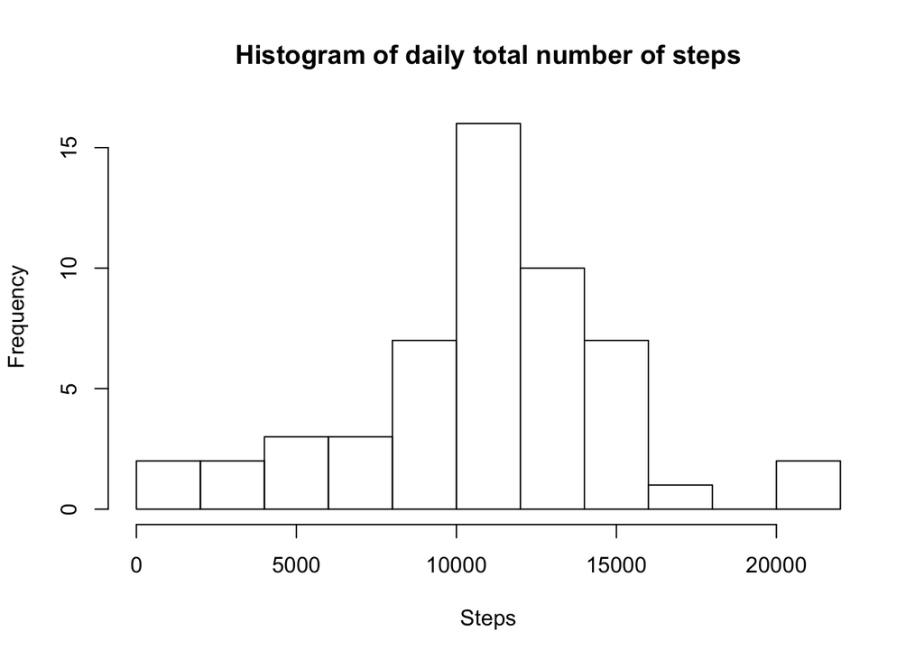

```r
daily_total <- tapply(activity$steps,as.factor(activity$date),sum)
hist(daily_total, main="Histogram of daily total number of steps",xlab="Steps",breaks=10)
```

```r
daily_total_mean <- round(mean(daily_total,na.rm=T))
daily_total_median <- round(median(daily_total,na.rm=T))
```

The mean of the daily total number of steps is 10766 and the median is 10765.

### Calculate the daily average activity pattern

Now I calculate the daily average pattern, again using the tapply function, which is then plotted.

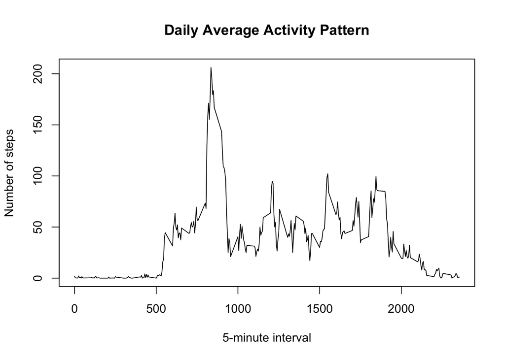

```r
daily_ave_pattern <- tapply(activity$steps,as.factor(activity$interval),mean,na.rm=T)
plot(names(daily_ave_pattern),daily_ave_pattern,type='l',main='Daily Average Activity Pattern',xlab='5-minute interval',ylab='Number of steps')
```

To find the 5-minute interval that, on average, has the highest number of steps per day, we can use the function which.max on the daily average pattern.

```r
ave_max <- names(daily_ave_pattern)[which.max(daily_ave_pattern)]
```

The most active 5-minute interval, on average, is the 835 interval.

### Imputing missing values

First I calculate the total number of missing values.

```r
total_missing_values <- length(which(is.na(activity$steps)))
```

The total number of missing values is: 2304.

Next I fill in the missing values by replacing them with the mean for that 5-minute interval.

```r
activity2 <- activity
for (i in 1:nrow(activity)){
  if (is.na(activity[i,1])) activity2[i,1] <- round(mean(activity[which(activity[,3]==activity[i,3]),1],na.rm=T))
}
```

I now recalculate the daily total number of steps with the new dataset without missing values and plot the histogram.

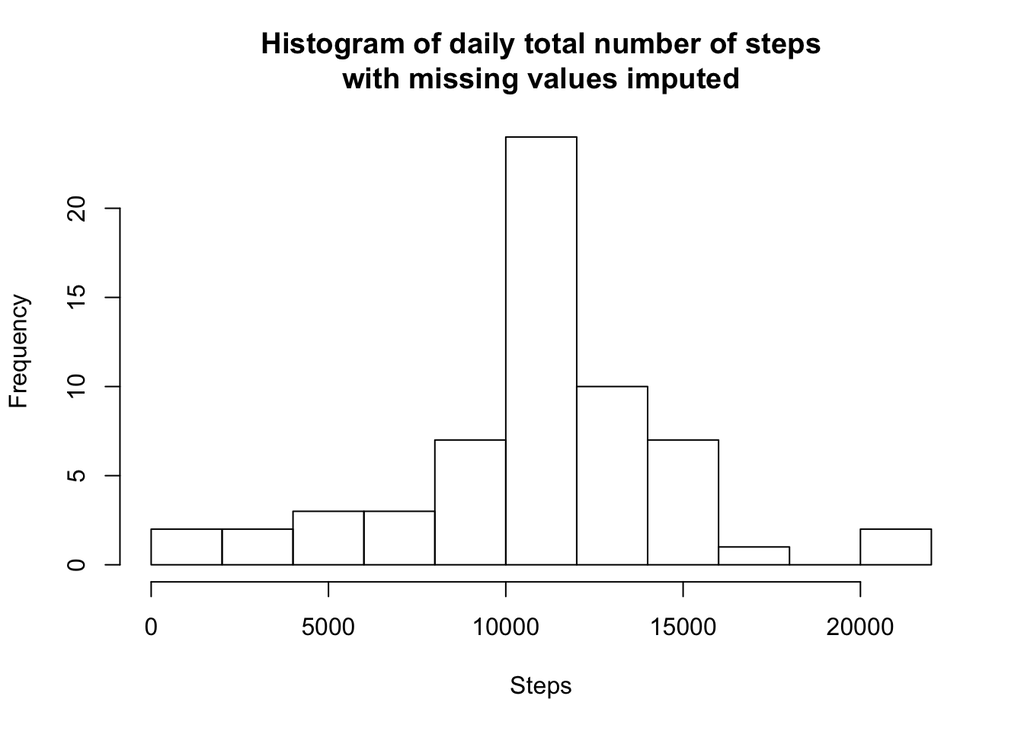

```r
daily_total2 <- tapply(activity2$steps,as.factor(activity2$date),sum)
hist(daily_total2, main="Histogram of daily total number of steps\nwith missing values imputed",xlab="Steps",breaks=10)
```

```r
daily_total_mean2 <- round(mean(daily_total2))
daily_total_median2 <- round(median(daily_total2))
```

The new mean of the daily total is now 10766 and the new median is 10762. To compare with the previous mean and median, let’s make a table:

```r
summary <- matrix(round(c(daily_total_mean,daily_total_median,daily_total_mean2,daily_total_median2)),nrow=2,dimnames=list(c("With NAs","Without NAs"),c("Mean","Median")))
library(xtable)
xt <- xtable(summary)
print(xt,type="html")
```

[output not shown]

### Finding differences in activity patterns between weekdays and weekends

To separate the weekdays and weekends we can use the function weekdays on the date.

```r
wk <- weekdays(activity2$date)
wk[which(wk=="Saturday" | wk=="Sunday")] <- "weekend"
wk[which(! wk=="weekend")] <- "weekday"
weekday <- as.factor(wk)
activity2 <- cbind(activity2,weekday)
```

Now we can plot the time series separately for weekdays and weekends to see if there is a difference in activity patterns.

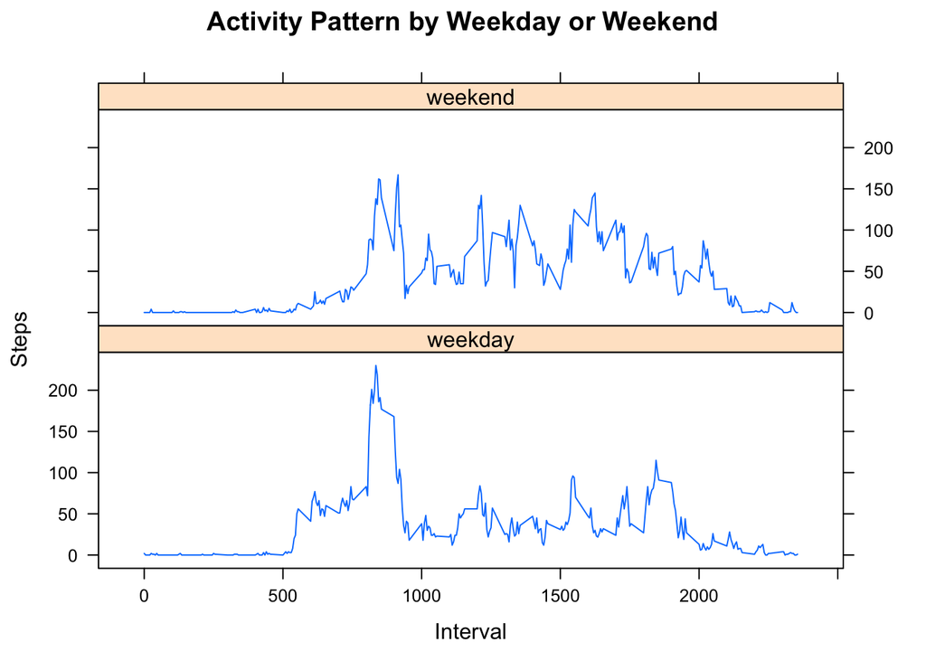

```r
weekday_weekend_pattern <- round(tapply(activity2$steps,list(as.factor(activity2$interval),activity2$weekday),mean,na.rm=T))
library(reshape2)
weekday_weekend_pattern2 <- melt(weekday_weekend_pattern)
colnames(weekday_weekend_pattern2) <- c("Interval","Weekday","Steps")
library(lattice)
xyplot(Steps ~ Interval|Weekday, data=weekday_weekend_pattern2, main="Activity Pattern by Weekday or Weekend",type='l',layout=c(1,2))
```